# 중첩의 원리가 무너지는 자리

자본흐름을 등가회로로 만들면 무엇이 재현되고 무엇이 끝내 재현되지 않는가 — 전자기학(회로망) × 금융경제학(가격형성) × 수치해석(적분 안정성)

저자

Insight Lab × Claude

공개

2026년 9월 9일

**노트핵심 문장**

’중첩’은 이 글에서 두 번 쓰인다. 하나는 전자기학과 경제학이 **겹치는** 자리이고, 다른 하나는 회로망이 따르는 **중첩의 원리**(superposition)다. 자본흐름을 $RLC$ 등가회로로 옮기면 감쇠와 두 유역의 결합은 정확히 재현된다. 그러나 시장의 다중프랙탈 간헐성은 **어떤 안정한 회로 구성으로도 재현되지 않았다.** 이유는 회로가 틀려서가 아니라 회로가 옳기 때문이다. 중첩의 원리가 성립하는 계는 스케일을 가로지르는 **곱셈적** 캐스케이드를 만들 수 없다. 그리고 이 글은 그 결론에 이르기 전에, 재현에 성공한 것처럼 보였던 결과가 **적분 스텝을 덜 준 산물**이었음을 먼저 기록한다.

# 1 왜 회로인가 — 유추가 아니라 같은 방정식이다

유체와 회로가 닮았다는 말은 비유가 아니다. 둘은 **같은 2차 미분방정식**을 푼다.

$$L\ddot q + R\dot q + \frac{q}{C} = V(t)$$

여기에 시장을 넣으면 각 항이 관측 가능한 양이 된다. 전류 $I=\dot q$는 수익률, 축적된 전하 $q$는 로그가격, 저항 $R$은 실현변동성, 인덕턴스 $L$은 모멘텀, 커패시턴스 $C$는 밸류에이션 복원력, 전원 $V(t)$는 외생 수급이다.

이 대응에서 **레이놀즈 수는 품질계수 $Q=\omega_0 L/R$와 같은 자리**에 놓인다. 유체역학에서 $Re$가 관성 대 점성의 비였듯, 회로에서 $Q$는 저장 대 소산의 비다.

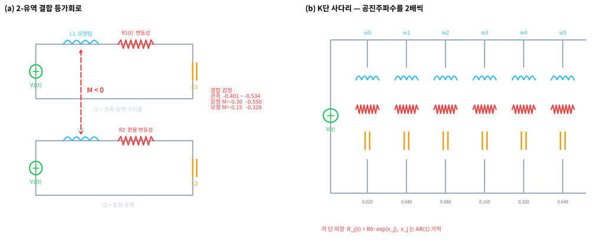

그림 1: 자본흐름 등가회로. (a) 원화 유역과 통화 유역을 음의 상호 인덕턴스 M으로 묶은 2-루프 구성. (b) 공진주파수를 기하급수로 배치한 K단 사다리. 출처: waterfirst/ns-capital-flow · analysis/draw_circuit.py

# 2 재현된 것 — 감쇠와 결합

두 가지는 회로가 정확히 잡아낸다.

**첫째, 시장은 세 국면 모두 과감쇠(overdamped)다.** 감쇠비 $\zeta_d = R/(2\sqrt{L/C})$를 관측 변동성으로 계산하면 상승기 1.66, 급락기 3.93, 정체기 4.12다. $\zeta_d>1$이면 진동조차 하지 못하고 지수적으로 죽는다. 폭락은 계가 **더 과감쇠로 밀린 사건**이다. 소용돌이가 커진 것이 아니라 유체가 걸쭉해진 것이다.

**둘째, 음의 상호 인덕턴스가 통화 결합을 설명한다.** 원화 자산과 달러 자산을 두 유역으로 놓고 상호 인덕턴스 $M$으로 묶으면, $M=-0.30$에서 두 전류의 상관이 $-0.550$이 된다. 실측된 주가–환율 상관은 국면별로 $-0.401 \sim -0.534$다.

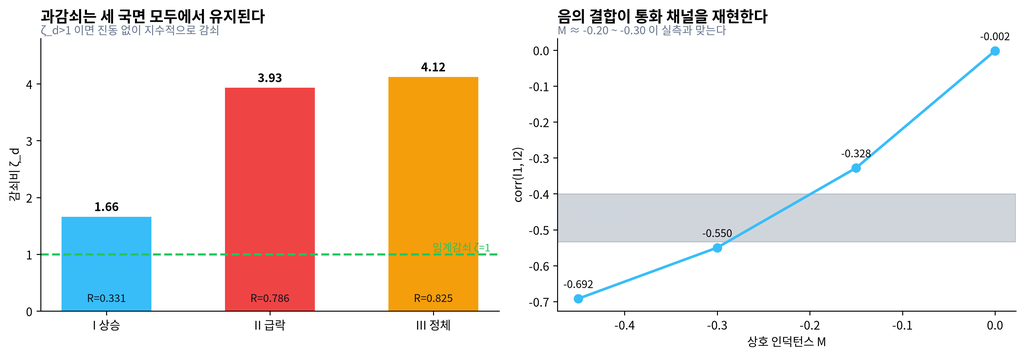

그림 2: 왼쪽: 국면별 감쇠비. 세 국면 모두 임계값 1을 넘어 과감쇠 영역에 있고, 급락기에 더 깊이 들어간다. 오른쪽: 상호 인덕턴스 M에 대한 두 유역 전류의 상관. 회색 띠가 실측 구간(-0.401~-0.534)이며 M은 대략 -0.20~-0.30에 대응한다.

# 3 재현되지 않은 것 — 간헐성

시장 수익률은 단일 스케일 과정이 아니다. 구조함수 $S_q(\tau)=\langle|\Delta_\tau \log P|^q\rangle \sim \tau^{\zeta(q)}$에서 $\zeta(q)$가 $q$에 선형이면 단일프랙탈, 오목하면 다중프랙탈이다. KOSPI 실측은 뚜렷이 오목하다. 선형이라면 $\zeta(6)=6\zeta(1)=3.21$이어야 하는데 실측은 **2.010**이다.

간헐성을 $\zeta(6)-6\zeta(1)$로 재면 실측은 **−1.200**이다.

여기서 첫 가설을 세웠다. **저항이 전류에 의존하면(즉 비선형 소자를 넣으면) 간헐성이 생길 것이다.** 변동성이 커질수록 마찰이 커지는 시장의 성질을 $R=R_0+\alpha|I|$로 옮긴 것이다.

기각되었다.

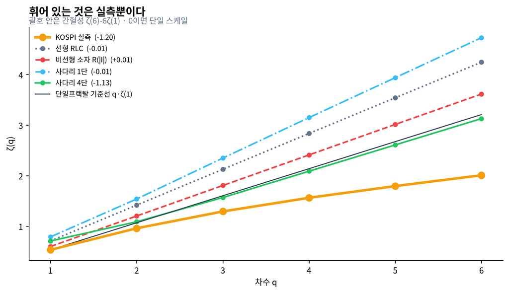

그림 3: 구조함수 지수 비교. 실측만 아래로 휘어 있고, 선형 RLC·비선형 소자·사다리 1단은 모두 직선(단일프랙탈)에 붙는다. 사다리 4단만 실측 곡률에 근접하나 다음 그림에서 보듯 재현 가능하지 않다.

선형 RLC는 −0.01, 비선형 소자를 넣어도 +0.01이다. **소자를 비선형으로 바꾸는 것으로는 간헐성이 만들어지지 않는다.** 순간적 비선형성은 진폭을 조절할 뿐, 스케일을 가로지르는 구조를 만들지 못한다.

# 4 실패보다 먼저 기록해야 할 것 — 수치가 만든 신기루

두 번째 가설은 회로의 **위상**을 바꾸는 것이었다. 공진주파수를 2배씩 기하급수로 배치한 $K$단 사다리를 만들면 스케일이 여러 개 생기므로 캐스케이드가 나오리라 보았다.

처음 계산에서는 성공한 듯 보였다. $K=1$에서 +0.28, $K=3$에서 −0.50, $K=6$에서 **−2.09**. 단수를 늘릴수록 간헐성이 커지는 깨끗한 단조 관계였고, 실측 −1.200을 사이에 두고 지나갔다.

**틀렸다.** 고주파 단에서 적분 스텝이 부족했을 뿐이다. 최고 주파수 $\omega_{max}$와 스텝 $h$의 곱이 0.06 수준이면 그 단은 경계적으로 불안정해지고, 발산 직전의 진동이 두꺼운 꼬리처럼 보인다. $\omega_{max}h \le 0.02$를 강제하고 시드 24개로 표준오차를 붙이자 결과가 뒤집혔다.

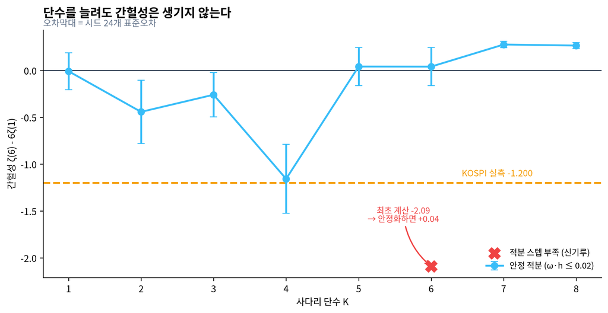

그림 4: 사다리 단수에 대한 간헐성. 오차막대는 시드 24개의 표준오차. K>=5 에서 간헐성이 0 부근으로 돌아가고 단조성은 없다. K=4 만 실측선에 닿으나 인접 단수와 부호가 갈리므로 메커니즘이 아니라 우연으로 본다. 붉은 점은 적분 스텝이 부족했던 최초 계산.

$K=4$가 −1.157로 실측에 가깝지만, 바로 옆 $K=5$가 +0.042다. 인접한 단수에서 부호가 갈리는 값은 메커니즘이 아니라 표본의 우연이다.

# 5 경계에서 나오는 명제 — 중첩의 원리

왜 실패했는가. 회로가 부족해서가 아니라 **회로가 정확히 회로이기 때문**이다.

회로망 이론의 첫 정리는 중첩의 원리다. 선형 소자로 이루어진 망에서 여러 전원의 응답은 각 전원의 응답을 **더한 것**과 같다. 사다리를 몇 단 쌓든, 각 단의 전류는 합산될 뿐 서로를 **곱하지 않는다.**

그런데 다중프랙탈은 정의상 곱셈적 구조다. 큰 스케일의 변동이 작은 스케일의 변동 **크기 자체를 조절**해야 $\zeta(q)$가 휜다. 덧셈적 결합은 아무리 많이 쌓아도 유효 분산을 바꿀 뿐 스케일 간 의존을 만들지 못한다.

**노트경계 명제**

전기공학은 “비선형성은 소자에서 온다”고 가르친다. 이 분석은 그 명제를 시장에 적용하려다 실패했고, 실패의 방식이 답을 준다. **시장의 간헐성은 소자의 비선형성에서도, 회로의 위상에서도 오지 않는다. 중첩의 원리를 따르는 계에서는 원리적으로 나올 수 없다.** 회로 유추가 성립하는 정확한 경계가 여기다 — 감쇠와 결합까지는 회로이고, 스케일 간 곱셈이 시작되는 자리부터는 회로가 아니다.

이 저널은 앞서 SP11 시장 임피던스에서 회로 언어의 **전달함수** 쪽을 다뤘다. 대역별 이득은 선형 응답의 문제이고, 중첩의 원리가 성립하는 영역이다. 이 글이 다룬 것은 그 영역이 **끝나는 자리**다.

그리고 SP21 정치의 복원력과는 정확히 짝을 이룬다. 정치체제는 단일 진동자의 복원력 $-kx$로 설명되었다. 시장은 단일 진동자로도, 진동자를 여러 개 엮어도 설명되지 않는다. 같은 2차계 언어가 한쪽에서는 충분하고 다른 쪽에서는 원리적으로 부족하다.

# 6 그래서 무엇이 남는가

회로 모델은 폐기 대상이 아니다. **적용 범위가 확정된 것**이다.

[output not shown]

간헐성을 담으려면 회로가 아니라 **곱셈적 캐스케이드 모형**이 필요하다. 다중프랙탈 랜덤워크가 그 계열이며, 이는 회로 방정식과 다른 대상이다.

**경고반대 해석과 한계**

**반대 해석 1 — 회로가 부족한 것이 아니라 내 회로가 부족했을 수 있다.** 여기서 시험한 것은 선형 소자·전류의존 저항·확률적 저항·기하급수 사다리 네 가지다. 비선형 커패시턴스, 능동 소자, 지연 되먹임을 넣은 구성은 시험하지 않았다. “회로로는 원리적으로 불가능하다”는 주장은 **중첩의 원리를 따르는 수동 선형망**에 한정된다. 능동 소자가 들어가면 중첩은 깨지고 결론도 달라질 수 있다.

**이 반대 해석은 발행 당일 부분적으로 검증되었다(7절 참조).**

**반대 해석 2 — $K=4$가 우연이 아닐 수도 있다.** 표준오차 0.368로 −1.157이며 실측 −1.200과 겹친다. 인접 단수와의 불일치를 근거로 우연이라 판정했으나, 시드를 수백 개로 늘리면 다른 그림이 나올 여지가 있다. 현재 판정은 24개 시드에 근거한 잠정이다.

**한계.** 실측 표본은 2025-06-04 ~ 2026-09-09의 310거래일 하나이며, 급락·정체 국면은 각 27~28일에 불과하다. 감쇠비 계산은 $\omega_0=0.10$이라는 임의 선택에 의존하므로 절대값이 아니라 국면 간 비율만 해석해야 한다. 시뮬레이션은 예측이 아니며, 어떤 결과도 매매에 적용하지 않았다.

**그리고 이 글 자체가 한 번 틀렸다.** 사다리가 간헐성을 재현한다는 결과를 먼저 얻었고 기록에 남겼다. 적분 해상도를 올리자 사라졌다. 수치 실험에서 “그럴듯한 결과”는 수렴을 확인하기 전까지 결과가 아니다.

# 7 후속 검정 — 빠진 항은 이류(advection)였다

발행 직후, 반대 해석 1을 직접 시험했다. 유체와 회로의 방정식을 항 단위로 나란히 놓으면 차이가 하나로 좁혀진다.

|  | 관성 | 소산 | 복원 | **이류 $(u\cdot\nabla)u$** | 강제 |
| --- | --- | --- | --- | --- | --- |
| 유체 | $\partial_t u$ | $\nu\nabla^2 u$ | $-\rho^{-1}\nabla p$ | **있음** | $f$ |
| 회로 | $L\ddot q$ | $R\dot q$ | $q/C$ | **없음** | $V(t)$ |
| 시장 | 모멘텀 | 변동성 마찰 | 밸류에이션 회귀 | **군집·자기수송** | 수급 |

회로에 이류항이 없다는 사실이 곧 중첩의 원리가 성립하는 이유다. 흐름이 자기 자신을 실어 나르지 않으므로 전류는 더해질 뿐 곱해지지 않는다.

**검정 1 — 집중정수 회로에 $\beta I\dot I$ 추가.** $\beta$를 0에서 120까지 올려도 간헐성은 −0.024에서 −0.131로 거의 움직이지 않았다. 집중정수에는 공간이 없어 공간 기울기를 표현할 수 없기 때문이다.

**검정 2 — 32노드 전송선에 이웃 간 이류 결합 추가.** 공간을 넣자 결과가 달라졌다.

| $\beta$ | 0 | 8 | 45 | **90** | 180 | 700 | 실측 |
| --- | --- | --- | --- | --- | --- | --- | --- |
| 간헐성 | +0.143 | −0.078 | −0.245 | **−0.303** | −0.186 | −0.120 | **−1.200** |
| ±SE | 0.121 | 0.029 | 0.030 | **0.026** | 0.028 | 0.021 | — |

간헐성이 실제로 발생하며 표준오차 ±0.03으로 0을 배제한다. 사다리에서 얻었던 신기루와 달리 이번 효과는 견고하다. 다만 $\beta\approx 90$에서 포화하고 **실측의 약 25%에 그친다.**

부족분의 후보 설명은 차원이다. 이 전송선은 1차원이고, 3차원 난류의 직접 캐스케이드를 만드는 와도 신장 항이 1차원에는 존재하지 않는다. 2·3차원 격자 검정은 하지 않았다.

**따라서 본문의 경계 명제는 유지되되 좁혀진다.** 중첩의 원리를 따르는 수동 선형망은 캐스케이드를 만들 수 없다. 그것을 깨는 항은 소자의 비선형성도 회로의 위상도 아니라 **공간을 가로지르는 자기수송**이다. 그리고 그 항만으로는 관측의 4분의 1밖에 설명되지 않는다.

# 8 참고 문헌

- 분석 코드와 전 과정 재현: `waterfirst/ns-capital-flow` · `analysis/` (`circuit_model.py`, `circuit_ladder.py`, `ladder_sweep.py`, `currency_flow.py`, `turbulence_test.py`)
- S. Ghashghaie, W. Breymann, J. Peinke, P. Talkner, Y. Dodge, *Turbulent cascades in foreign exchange markets*, **Nature** 381, 767–770 (1996)
- A. N. Kolmogorov, 국소 등방성 난류의 스케일링 법칙 (1941)
- E. Bacry, J. Delour, J. F. Muzy, *Multifractal random walk*, Phys. Rev. E 64 (2001)
- Insight Lab SP21 — 정치의 복원력과 진동방정식
- 시장 데이터: Yahoo Finance (`^KS11`, `KRW=X`, 국내 섹터 ETF 10종), 2025-06-04 ~ 2026-09-09